# Reproducible Research

Amy

08/12/2020

## Package loading

Load required packages

```r
library(dplyr)
```

```r
library(ggplot2)
library(gridExtra)
```

## Data Processing

First the data is downloaded and read as a CSV file into the global environment.

Event types are very varied, in order to not cloud the data, only events specifically listed in the documentation 7. Event Types will be included. (Stored in variable ‘events’)

```r
#Download and read in data if not already in environment
if (!exists('data')) {
  download.file("https://d396qusza40orc.cloudfront.net/repdata%2Fdata%2FStormData.csv.bz2", "Storm data.csv.bz2")
  data<-read.csv("Storm data.csv.bz2", na.strings = "?")
  write.csv(data, "Storm data.csv")
}
data<-read.csv("Storm data.csv")

events<-c("Astronomical Low Tide","Avalanche","Blizzard","Coastal Flood","Cold/Wind Chill","Debris Flow","Dense Fog", "Dense Smoke", "Drought", "Dust Devil", "Dust Storm", "Excessive Heat", "Extreme Cold/Wind Chill", "Flash Flood", "Flood", "Frost/Freeze", "Funnel Cloud", "Freezing Fog", "Hail", "Heat", "Heavy Rain", "Heavy Snow", "High Surf","High Wind", "Hurricane (Typhoon)", "Ice Storm", "Lake-Effect Snow","Lakeshore Flood", "Lightning","Marine Hail","Marine High Wind","Marine Strong Wind","Marine Thunderstorm Wind", "Rip Current", "Seiche","Sleet", "Storm Surge/Tide", "Strong Wind", "Thunderstorm Wind","Tornado", "Tropical Depression", "Tropical Storm", "Tsunami", "Volcanic Ash", "Waterspout", "Wildfire", "Winter Storm", "Winter Weather")
```

## Analysis

### Storm events ~ Population Health

Next, subset the data to answer the first question - which types of events are most harmful with respect to population health? I chose fatalities and injuries as markers of population health, although damages could also have been included. I summed fatalities and injuries into morbidity, then plotted the totals against the event type that caused them. This can be seen in plot 1.

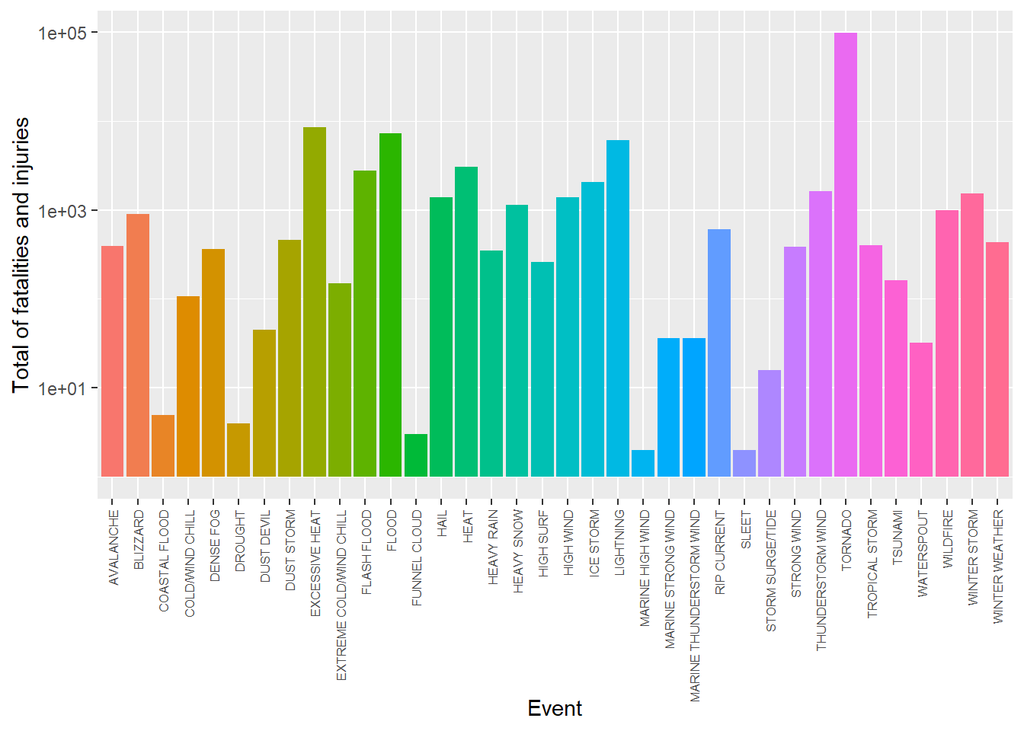

```r
popn<-data %>%
   select(EVTYPE, FATALITIES, INJURIES)
events<-toupper(events)
popn$EVTYPE<-toupper(popn$EVTYPE)
popn<-popn[which (popn$EVTYPE %in% events), ]
popn_sig<- popn %>%
  select(EVTYPE, FATALITIES, INJURIES) %>%
    group_by(EVTYPE) %>%
      summarise_all(sum)
popn_sig$MORBIDITY <- popn_sig$FATALITIES + popn_sig$INJURIES
popn_sig<- popn_sig %>%
  select(EVTYPE, MORBIDITY)
popn_sig<-popn_sig[which(popn_sig$MORBIDITY > 0),]
(plot1<-ggplot(data=popn_sig, aes(x=EVTYPE, y=MORBIDITY, fill=EVTYPE), color=popn_sig$EVTYPE) + geom_bar(stat="identity") + scale_y_continuous(trans='log10') + xlab("Event") + ylab("Total of fatalities and injuries") + theme(axis.text.x = element_text(size = 6, angle = 90, vjust = 0.5, hjust=1), legend.position="none"))
```

As can be seen from the above plot, tornadoes cause far more population damage than any other events. Other major causes of population damage are excessive heat, floods and lightning.

### Storm events ~ Economic Damage

Another subset of the data was taken to look at economic damage, this time looking at property and crop damage. A similar plot to above was produced.

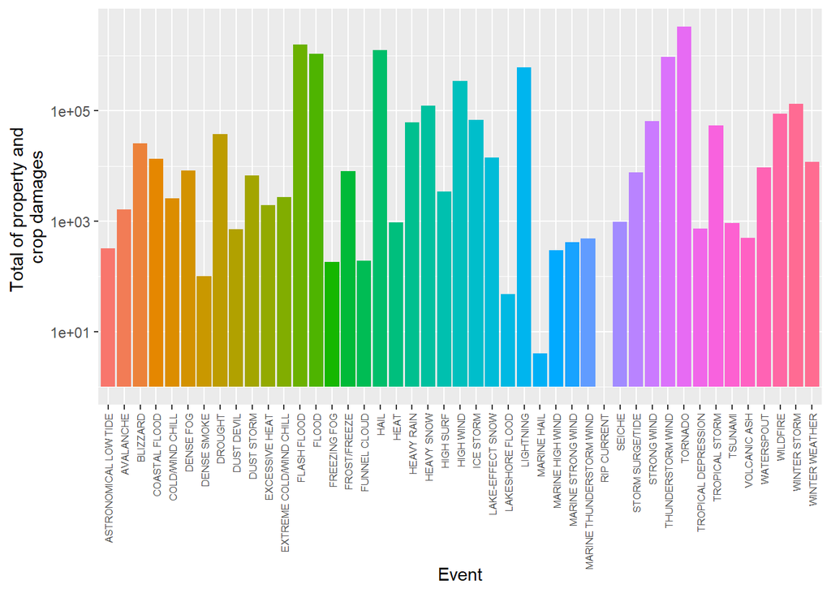

```r
econ<-data %>%
   select(EVTYPE, PROPDMG, CROPDMG)
econ$EVTYPE<-toupper(econ$EVTYPE)
econ<-econ[which (econ$EVTYPE %in% events), ]
econ_sig<- econ %>%
  select(EVTYPE, PROPDMG, CROPDMG) %>%
    group_by(EVTYPE) %>%
      summarise_all(sum)
econ_sig$ECON <- econ_sig$PROPDMG + econ_sig$CROPDMG
econ_sig<- econ_sig %>%
  select(EVTYPE, ECON)
econ_sig<-econ_sig[which(econ_sig$ECON > 0),]
(plot1<-ggplot(data=econ_sig, aes(x=EVTYPE, y=ECON, fill=EVTYPE)) + geom_bar(stat="identity") + scale_y_continuous(trans='log10') + xlab("Event") + ylab("Total of property and \ncrop damages") + theme(axis.text.x = element_text(size = 6, angle = 90, vjust = 0.5, hjust=1), legend.position="none"))
```

In conclusion, the main area of focus to prevent damages to people and properties is tornado damage prevention.